# Germanwings Reviews

## A Naive text summarization

Identify the most frequent words in a piece of text and use the occurrence of these words in sentences to rate the importance of a sentence.

```python
print(summariser(pressed_germanwings))
```

[output not shown]

## Summarizer based on lexical similarity: gensim

Gensim uses a network with sentences as nodes and 'lexical similarity' as weights on the arcs between nodes

```python
import gensim.summarization
print(gensim.summarization.summarize(pressed_germanwings, word_count=100))
```

```
The flights were on time, we got a snack and a seat with more legroom due to the Smart Fare booked and the staff was friendly.
.  Flight on time, booked smart fare which gave Extra Legroom seat, snack/drink and 23kg of hold luggage for a very good price.
Short wait at check in staff at desk/flight crew were friendly helpful and outgoing seats had surprisingly more room than I expected and luggage was on the carousel quickly.
I paid smart price which include a sandwich/small bottle water/one time juice or soft drink service cabin crew friendly and efficient.
```

### Germanwings and its peers

3-How do reviews of Germanwings compare to its peers?

[figure not shown]

```python
df.groupby("airline_code", as_index=False).review.count()
```

|  | airline_code | review |
| --- | --- | --- |
| 0 | air-berlin | 488 |
| 1 | british-airways | 2863 |
| 2 | eurowings | 275 |
| 3 | germanwings | 146 |
| 4 | klm-royal-dutch-airlines | 1002 |
| 5 | niki | 42 |
| 6 | ryanair | 1610 |
| 7 | vueling-airlines | 967 |

```python
peers = reviews[reviews["airline_code"].isin(peers_set)]
```

[output not shown]

```
Reviews of  air-berlin
```

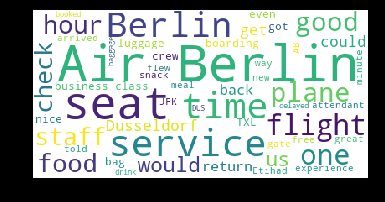

```
Reviews of  british-airways
```

[figure not shown]

```
Reviews of  eurowings
```

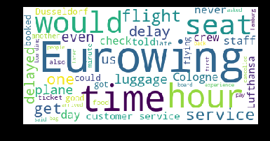

```
Reviews of  germanwings
```

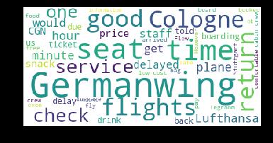

```
Reviews of  klm-royal-dutch-airlines
```

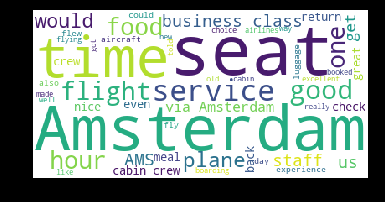

```
Reviews of  niki
```

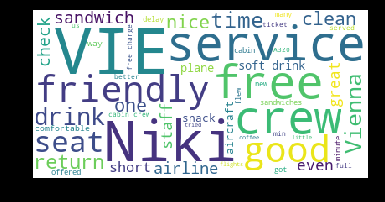

```
Reviews of  ryanair
```

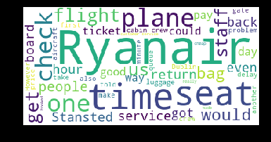

```
Reviews of  vueling-airlines
```

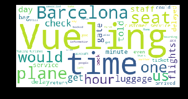

```python
for (review,airline_code) in zip(pressed_reviews["review"], pressed_reviews["airline_code"]):
    print("Reviews of ",airline_code)
    wordcloud(review)
```

- Sentiment analysis
  - Hu and Liu's sentiment analysis lexicon
  - Emotion analyzer using NRC data
  - Weighted word analysis using Vader

```python
pos_neg_freg_documents(pressed_reviews)
```

|  | airline_code | Positive | Negative | Net |
| --- | --- | --- | --- | --- |
| 0 | vueling-airlines | 1.9 | 2.7 | -0.8 |
| 1 | air-berlin | 3.1 | 2.3 | 0.8 |
| 2 | british-airways | 3.3 | 2.4 | 0.8 |
| 3 | eurowings | 2.1 | 2.6 | -0.6 |
| 4 | germanwings | 3.5 | 2.1 | 1.4 |
| 5 | klm-royal-dutch-airlines | 4.1 | 2.1 | 2.0 |
| 6 | niki | 5.5 | 1.8 | 3.7 |
| 7 | ryanair | 2.5 | 2.6 | -0.1 |

## Simple sentiment analysis using NRC data

NRC data codifies words with emotions where 14,182 words are coded into 2 sentiments and 8 emotions. For example, the word abandonment is associated with anger, fear, sadness and has a negative sentiment.

```python
emotion_dict['abandoned']
```

```
['anger', 'fear', 'negative', 'sadness']
```

```python
emotions = emotion_analyzer_documents(pressed_reviews)
emotions
```

|  | airline_code | anger | anticipation | disgust | fear | joy | negative | positive | sadness | surprise | trust |
| --- | --- | --- | --- | --- | --- | --- | --- | --- | --- | --- | --- |
| 0 | vueling-airlines | 0.01 | 0.02 | 0.01 | 0.01 | 0.01 | 0.02 | 0.03 | 0.01 | 0.01 | 0.02 |
| 1 | air-berlin | 0.01 | 0.02 | 0.01 | 0.01 | 0.02 | 0.02 | 0.04 | 0.01 | 0.01 | 0.03 |
| 2 | british-airways | 0.01 | 0.02 | 0.01 | 0.01 | 0.02 | 0.02 | 0.04 | 0.01 | 0.01 | 0.03 |
| 3 | eurowings | 0.01 | 0.02 | 0.01 | 0.01 | 0.01 | 0.02 | 0.03 | 0.01 | 0.01 | 0.02 |
| 4 | germanwings | 0.01 | 0.03 | 0.00 | 0.01 | 0.02 | 0.02 | 0.04 | 0.01 | 0.01 | 0.03 |
| 5 | klm-royal-dutch-airlines | 0.01 | 0.02 | 0.00 | 0.01 | 0.02 | 0.02 | 0.04 | 0.01 | 0.01 | 0.03 |
| 6 | niki | 0.01 | 0.02 | 0.01 | 0.01 | 0.02 | 0.02 | 0.04 | 0.01 | 0.01 | 0.04 |
| 7 | ryanair | 0.01 | 0.02 | 0.01 | 0.01 | 0.02 | 0.02 | 0.03 | 0.01 | 0.01 | 0.02 |

## Weighted word analysis using Vader

Vader contains a list of 7500 features weighted by how positive or negative they are. It uses these features to calculate stats on how positive, negative and neutral a passage is. And combines these results to give a compound sentiment (higher = more positive) for the passage. Human trained on twitter data and generally considered good for informal communication. 10 humans rated each feature in each tweet in context from -4 to +4.

- Calculates the sentiment in a sentence using word order analysis: "marginally good" will get a lower positive score than "extremely good"
- Computes a "compound" score based on heuristics (between -1 and +1)
- Includes sentiment of emoticons, punctuation, and other 'social media' lexicon elements

```python
vader_comparison(pressed_reviews)
```

|  | airline_code | Neutral | Positive | Negative | Compound |
| --- | --- | --- | --- | --- | --- |
| 0 | air-berlin | 0.81 | 0.10 | 0.08 | 0.04 |
| 1 | british-airways | 0.81 | 0.11 | 0.08 | 0.05 |
| 2 | eurowings | 0.81 | 0.08 | 0.11 | -0.03 |
| 3 | germanwings | 0.80 | 0.11 | 0.07 | 0.07 |
| 4 | klm-royal-dutch-airlines | 0.79 | 0.14 | 0.07 | 0.12 |
| 5 | niki | 0.77 | 0.17 | 0.06 | 0.18 |
| 6 | ryanair | 0.82 | 0.09 | 0.09 | 0.02 |
| 7 | vueling-airlines | 0.82 | 0.06 | 0.11 | -0.07 |

### Beyond reviews

4-Reviews aside, what are five most relevant features predicting a recommendation?

- Horse race between three supervised models

```python
display(data.head(1))
```

|  | country | date_published | review_count | route | seat_type | traveller_type | days_after_crash | airline_code | recommended |
| --- | --- | --- | --- | --- | --- | --- | --- | --- | --- |
| 0 | Australia | 2018-07-12 | 0 | Florence to London via Dusseldorf | Economy Class | Solo Leisure | 1206 | air-berlin | 0.0 |

```
array([[<matplotlib.axes._subplots.AxesSubplot object at 0x1a2013f1d0>,
      dtype=object)
```

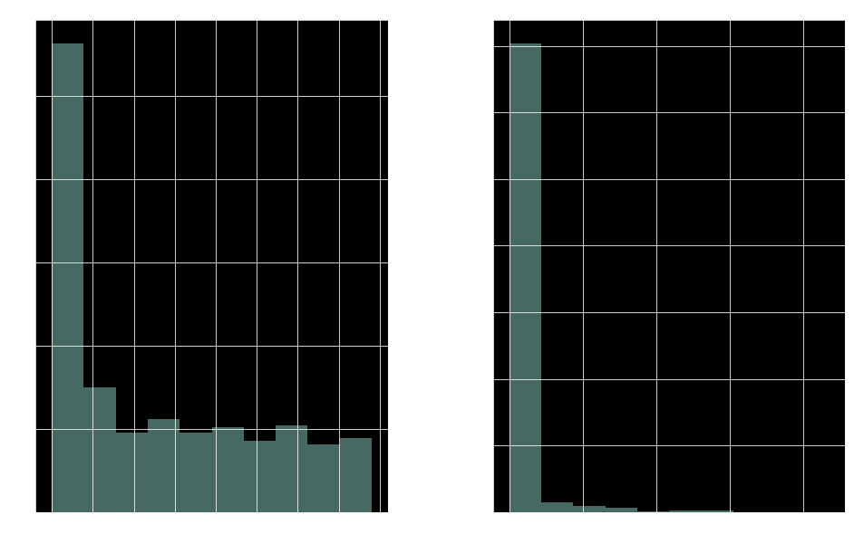

```python
# Split the data into features and target label
recommended = data['recommended']
features_raw = data.drop('recommended', axis = 1)

# Visualize skewed continuous features of original data
features_raw.hist(alpha=0.5, figsize=(16, 10))
```

```
array([[<matplotlib.axes._subplots.AxesSubplot object at 0x1a2136dc88>,
      dtype=object)
```

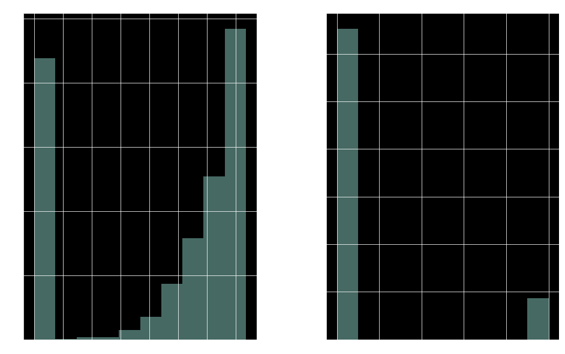

```python
# Log-transform the skewed features
skewed = ['days_after_crash', 'review_count']
features_transformed = pd.DataFrame(data = features_raw)
features_transformed['days_after_crash'] = features_raw['days_after_crash'].apply(lambda x: np.log(x + 1))
features_transformed['review_count'] = (features_raw['review_count'] > 0).astype(np.float32)

# Visualize the new log distributions
features_transformed.hist(alpha=0.5, figsize=(16, 10))
```

```python
from sklearn.tree import DecisionTreeClassifier
from sklearn.ensemble import AdaBoostClassifier
from sklearn.ensemble import RandomForestClassifier
from sklearn.linear_model import LogisticRegression

# Initialize the three models
clf_A = LogisticRegression(random_state=0)
clf_B = RandomForestClassifier(random_state=0)
clf_C = AdaBoostClassifier(random_state=0)

# T number of samples for 1%, 10%, and 100% of the training data
samples_100 = len(y_train)
samples_10 = int(0.10*len(y_train))
samples_1 = int(0.01*len(y_train))

# Collect results on the learners
results = {}
for clf in [clf_A, clf_B, clf_C]:
    clf_name = clf.__class__.__name__
    results[clf_name] = {}
    for i, samples in enumerate([samples_1, samples_10, samples_100]):
        results[clf_name][i] = \
        train_predict(clf, samples, X_train, y_train, X_test, y_test)
```

```
LogisticRegression trained on 59 samples.
LogisticRegression trained on 591 samples.
LogisticRegression trained on 5914 samples.
RandomForestClassifier trained on 59 samples.
RandomForestClassifier trained on 591 samples.
RandomForestClassifier trained on 5914 samples.
AdaBoostClassifier trained on 59 samples.
AdaBoostClassifier trained on 591 samples.
AdaBoostClassifier trained on 5914 samples.
```

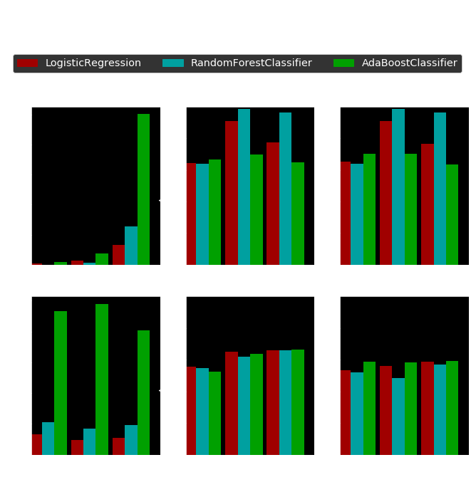

```python
# Run metrics visualization for the three supervised learning models chosen
import visuals as vs
vs.evaluate(results)
```

Implementation: Model Tuning

```python
from sklearn.model_selection import GridSearchCV
from sklearn.metrics import make_scorer
from sklearn.pipeline import Pipeline

# Initialize the classifier
clf = AdaBoostClassifier(random_state=0)

# Parameters list to tune
parameters = {
    "n_estimators" : [50, 200],
    "learning_rate": [0.4, 0.7]
}

#[
#    {'classifier' : [LogisticRegression(random_state=0)],
#     'classifier__penalty' : ['l1', 'l2'],
#    'classifier__C' : np.logspace(-4, 4, 20),
#    'classifier__solver' : ['liblinear']},
#    {'classifier' : [RandomForestClassifier(random_state=0)],
#    'classifier__n_estimators' : list(range(10,101,10)),
#    'classifier__max_features' : list(range(6,32,5))}
#]

# Make an fbeta_score scoring object
scorer = make_scorer(fbeta_score, beta=1)

grid_obj = GridSearchCV(clf, parameters, scorer)
grid_fit = grid_obj.fit(X_train, y_train)
best_clf = grid_fit.best_estimator_

# Predictions using the unoptimized and model
predictions = (clf.fit(X_train, y_train)).predict(X_test)
best_predictions = best_clf.predict(X_test)
```

```python
from sklearn.metrics import accuracy_score, precision_score, recall_score, f1_score
print("Final accuracy score on the testing data: {:.4f}".format(accuracy_score(y_test, best_predictions)))
print("Final F1-score on the testing data: {:.4f}".format(f1_score(y_test, best_predictions)))
```

```
Final accuracy score on the testing data: 0.6606
Final F1-score on the testing data: 0.5803
```

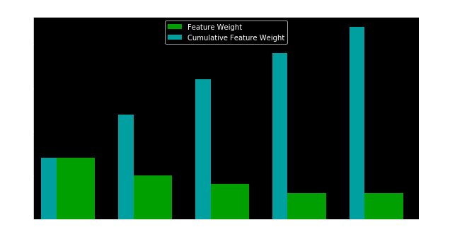

```
['days_after_crash' 'review_count' 'traveller_type_Business'
 'airline_code_vueling-airlines' 'airline_code_klm-royal-dutch-airlines']
```

```python
from sklearn.ensemble import AdaBoostClassifier
from sklearn.ensemble import RandomForestClassifier

model = best_clf
importances = model.feature_importances_

vs.feature_plot(importances, X_train, y_train)

indices = np.argsort(importances)[::-1]
columns = X_train.columns.values[indices[:5]]
values = importances[indices][:5]
print(columns)
```

Feature Selection

```python
from sklearn.base import clone

# Reduce the feature space
X_train_reduced = X_train[X_train.columns.values[(np.argsort(importances)[::-1])[:5]]]
X_test_reduced = X_test[X_test.columns.values[(np.argsort(importances)[::-1])[:5]]]

clf = (clone(best_clf)).fit(X_train_reduced, y_train)

reduced_predictions = clf.predict(X_test_reduced)

# Report scores from the final model using both versions of data
print("Final Model trained on full data\n------")
print("Accuracy on testing data: {:.4f}".format(accuracy_score(y_test, best_predictions)))
print("F1-score on testing data: {:.4f}".format(f1_score(y_test, best_predictions)))
print("\nFinal Model trained on reduced data\n------")
print("Accuracy on testing data: {:.4f}".format(accuracy_score(y_test, reduced_predictions)))
print("F1-score on testing data: {:.4f}".format(f1_score(y_test, reduced_predictions)))
```

```
Final Model trained on full data
------
Accuracy on testing data: 0.6606
F1-score on testing data: 0.5803

Final Model trained on reduced data
------
Accuracy on testing data: 0.6572
F1-score on testing data: 0.5813
```

# Next Steps:

- Change date formats
- Fixed effects: Airline, airport, route
- Combined text and feature analysis
- Airline revenue data and ticket prices data

#### Germanwings reviews

1-What are top words predicting a positive or negative review?

```
* Positive: compartments, satisfied, saturday, move \ seat, good, enough, legroom, snack
* Negative: landing, lane, language, lasts \ two, agents, available, cologne, process
```

2-What are top concerns of reviewrs?

```
* Boarding, delays
```

#### Germanwings and its peers

3-How does reviews of Germanwings compare to its peers?

```
* It seems above average
```

#### Beyond reviews

4-Reviews aside, what are five most relevant features predicting a recommendation?

```
* Crash date, review count, traveller type, airline
```

```python
import os
current_path = os.getcwd()
path = current_path + "/07_Slides.ipynb"
path
print("jupyter nbconvert ", path," --to slides --post serve\n--SlidesExporter.reveal_theme=serif \n--SlidesExporter.reveal_scroll=True \n--SlidesExporter.reveal_transition=none")
```

[output not shown]

```python
jupyter nbconvert  /Users/moradi/Dropbox/software/German_wings/zeroG_slides.ipynb  --to slides --post serve --SlidesExporter.reveal_theme=serif --SlidesExporter.reveal_scroll=True --SlidesExporter.reveal_transition=none
```